# Multilevel and hierarchical models

Shrinkage, partial pooling, and mixed linear models

| Diogo Melo Lewis-Sigler Institute of Integrative Genomics damelo@princeton.edu |
| --- |

### Multilevel models

- Multilevel models introduce structure to the parameter distribution
- Allows us to model several common processes
  - Repeated measures of the same individual
  - Block designs (some observations more similar than others)
  - Pseudo-replicates
  - Correlated observations
- Even in the absence of this type of structure, multilevel models can improve model performance

### baseball in ulam

```python
m1 = ulam(alist(
  hits ~ binomial(at_bats, avgs),
  avgs <- p[player],
  p[player] ~ beta(nu0, nu1),
  nu0 ~ lognormal(0, 1),
  nu1 ~ lognormal(0, 1)
), data = list(hits = d[,2],
               at_bats = d[,1],
               player = 1:N_players),
chains = 4, cores = 4, iter = 2000)
```

### Batting averages

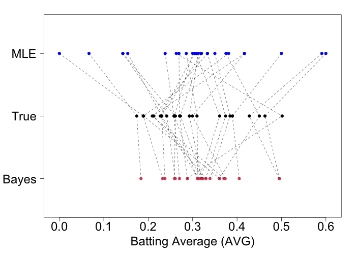

- Extreme estimates are “shrunk” towards the mean

### Shrinkage and types of pooling

(1) **Complete pooling** - Only one estimate for all players (underfitting)

(2) **No pooling** - Players are all independent, no information is shared (overfitting)

(3) **Partial pooling** - Players' estimates help inform each other. This means using an adaptive regularizing prior, as in the previous example.

### Blocked experimental designs

### Prosociality in chimps

- Prosociality refers to behaviors that are intended to benefit others.
- We can test for the presence of prosociality experimentally
- The set up allows for a subject to decide to give food to a partner or not, with no cost to himself.

### Experimental setup

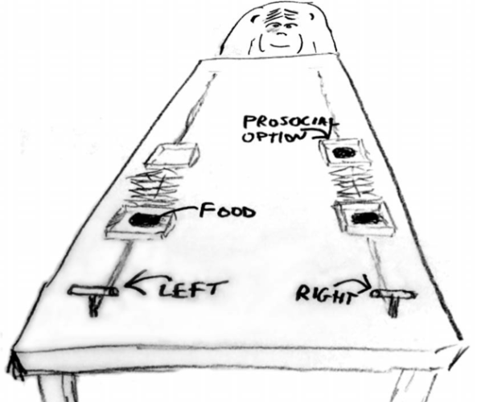

### data structure

- Several measures per individual chimp (actor)
- Condition (social or non-social)
- Experimental blocks
- Prosocial option on the left (chimps are left- or right-handed)

Outcomes:

- Chose prosocial option
- Pulled left

### chimp data

```python
> library(rethinking)
> data(chimpanzees)
> head(chimpanzees)
  actor recipient condition block trial prosoc_left chose_prosoc pulled_left
1     1        NA         0     1     2           0            1           0
2     1        NA         0     1     4           0            0           1
3     1        NA         0     1     6           1            0           0
4     1        NA         0     1     8           0            1           0
5     1        NA         0     1    10           1            1           1
6     1        NA         0     1    12           1            1           1
```

### experimental treatments

(1) prosoc_left= 0 and condition= 0: Two food items on right and no partner.

(2) prosoc_left= 1 and condition= 0: Two food items on left and no partner.

(3) prosoc_left= 0 and condition= 1: Two food items on right and partner present.

(4) prosoc_left= 1 and condition= 1: Two food items on left and partner present.

### Prior for the experimental treatment

### Pooling the estimates for actor

### Pooling the estimates for block

### All the missing priors

### chimp Model code

```python
## Data
dat_list <- list(
  pulled_left = d$pulled_left,
  actor = d$actor,
  block_id = d$block,
  treatment = as.integer(d$treatment) )

## Model
m1 <- ulam(
    alist(
        pulled_left ~ dbinom( 1 , p ) ,
        logit(p) <- a[actor] + g[block_id] + b[treatment] ,
        b[treatment] ~ dnorm( 0 , 0.5 ),
      ## regularizing multi level priors
        a[actor] ~ dnorm( a_0 , sigma_a ),
        g[block_id] ~ dnorm( 0 , sigma_g ),
      ## hyper-priors
        a_0 ~ dnorm( 0 , 1.5 ),
        sigma_a ~ dexp(1),
        sigma_g ~ dexp(1)
    ) , data=dat_list , chains=4 , cores=4 , log_lik=TRUE )
```

### Actor estimates

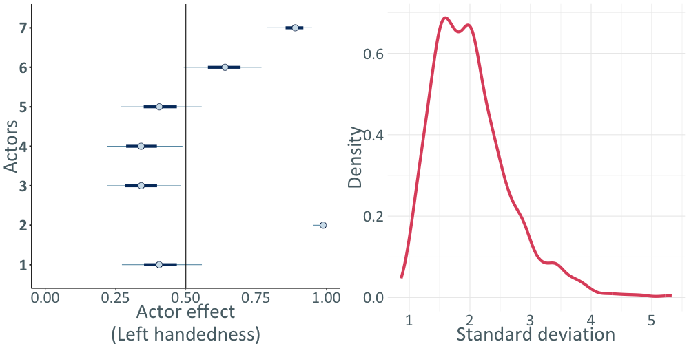

### Block estimates

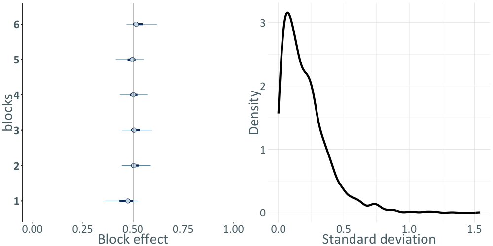

### Random effects standard deviations

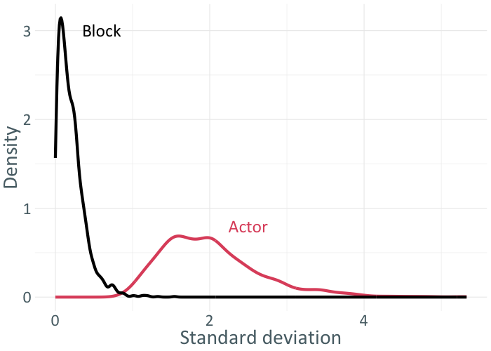

### treatment effects

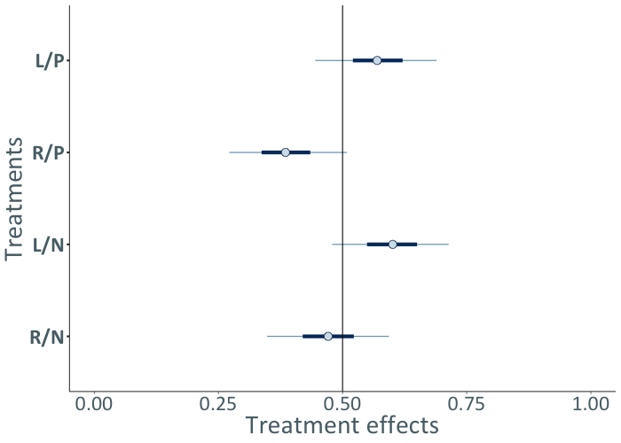

### treatment contrasts

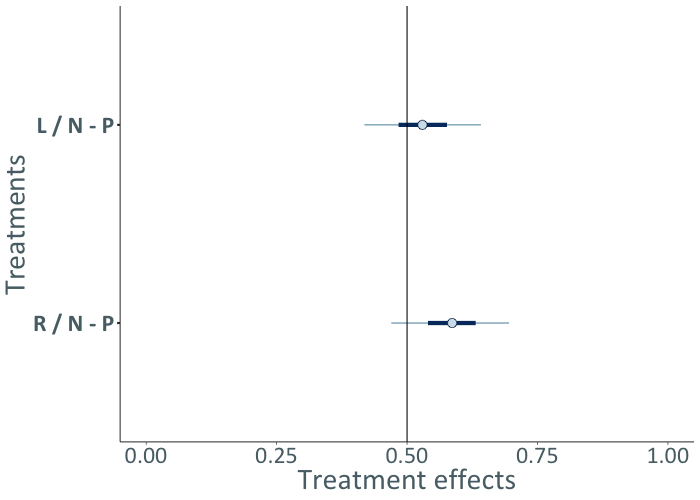

### Centered pooled effect

### non-Centered pooled effect

### Non-Centered chimp model

```python
m1nc <- ulam(
  alist(
    pulled_left ~ dbinom( 1 , p ) ,
    logit(p) <- a_0 + z[actor]*sigma_a +
                x[block_id]*sigma_g +
                b[treatment] ,
    b[treatment] ~ dnorm( 0 , 0.5 ),
    z[actor] ~ dnorm( 0 , 1 ),
    x[block_id] ~ dnorm( 0 , 1 ),
    a_0 ~ dnorm( 0 , 1.5 ),
    sigma_a ~ dexp(1),
    sigma_g ~ dexp(1),
    gq> vector[actor]:a <<- a_0 + z*sigma_a, # actor intercepts
    gq> vector[block_id]:g <<- x*sigma_g     # block intercepts
  ) , data=dat_list , chains=4 , cores=4 )
```

### Random slopes model

### Replicated data

### Correlated random effects

### Phylogenetic models and Gaussian processes